# Color Analysis of Floral Tissues

## 4.17 Format PC Scores

```r
# Replace 'x' with '_' in row names
rownames(pca_bract) <- gsub("x", "_", rownames(pca_bract))
rownames(pca_petal) <- gsub("x", "_", rownames(pca_petal))
rownames(pca_labellum) <- gsub("x", "_", rownames(pca_labellum))

# Convert row names to a column named 'id'
pca_bract <- pca_bract %>% rownames_to_column(var = "id")
pca_petal <- pca_petal %>% rownames_to_column(var = "id")
pca_labellum <- pca_labellum %>% rownames_to_column(var = "id")
```

## 4.18 Spectral Descriptors

We compute various spectral descriptors to quantify the color properties of the floral tissues.

## 4.19 Define spectral descriptors

B1: Total brightness B2: Mean brightness B3: Intensity (Rmax) S1U to S1R: Relative contributions of UV, Violet, Blue, Green, Yellow, and Red spectral ranges to total brightness S2: Spectral saturation (Rmax/Rmin) S3: Chroma S4: Spectral purity S5: Chroma S6: Contrast (Rmax - Rmin) S7: Spectral saturation S8: Chroma ((Rmax - Rmin)/B2) S9: Carotenoid chroma ((R700 - R450)/R700) S10: Peaky chroma H1 to H5: Hue metrics (e.g., peak wavelength) Note: Some metrics may be sensitive to spectral noise.

## 4.20 Calculate Spectral Descriptors

### 4.20.1 Bract

```r
# Calculate spectral descriptors for bract
summary_bract <- summary(bract_spec_scalemax)

# Remove S2 due to infinite values
summary_bract <- summary_bract %>% select(-S2)

# Extract metrics for parents
bract125 <- round(summary_bract["125", ], 3)
bract126 <- round(summary_bract["126", ], 3)
bractBRAC <- round(summary_bract["BRAC", ], 3)
```

### 4.20.2 Plot Bract Spectral Descriptors Histograms

```r
pdf("./results/figures/bract_descriptors_histograms.pdf", width = 14, height = 10)

# Set up plotting area: 4 rows x 6 columns for histograms
par(mfrow = c(4, 6),        # 4 rows, 6 columns
    mar = c(5, 5, 4, 2) + 0.1,  # Margins for each plot: bottom, left, top, right
    oma = c(0, 0, 0, 5))    # Outer margins: bottom, left, top, right

# Loop through each metric and plot histogram with parental lines
for (i in 1:ncol(summary_bract)) {
  hist(summary_bract[, i],
       xlab = colnames(summary_bract)[i],
       main = colnames(summary_bract)[i],
       col = "lightgrey",
       border = "white")

  # Add vertical lines for parental samples
  abline(v = bract125[i], col = 'gold1', lwd = 3)      # C. lasius parent
  abline(v = bract126[i], col = 'gold1', lwd = 3)      # C. lasius parent
  abline(v = bractBRAC[i], col = 'darkgreen', lwd = 3) # C. bracteatus parent
}

# Allow drawing in the outer margin
par(xpd = TRUE)

plot.new()

# Add a shared legend in the outer right margin
legend("topright",
       inset = c(0, 0),  # Adjusts the position of the legend
       legend = c("C. lasius parent", "C. bracteatus parent"),
       col = c("gold1", "darkgreen"),
       lty = 1,              # Line type: solid
       lwd = 3,              # Line width
       cex = 1.5,            # Text size
       bty = "n")            # No box around the legend

# Close the PDF device to save the file
dev.off()
```

### 4.20.3 Petal Summary

```r
# Calculate summary statistics for petal
summary_petal <- summary(petal_spec_scalemax)

# Remove S2 due to infinite values
summary_petal <- summary_petal %>% select(-S2)

# Extract metrics for specific samples
petal125 <- round(summary_petal["125", ], 3)
petal126 <- round(summary_petal["126", ], 3)
petalBRAC <- round(summary_petal["BRAC", ], 3)
```

### 4.20.4 Plot Petal Spectral Descriptors Histograms

```r
pdf("./results/figures/petal_descriptors_histograms.pdf", width = 14, height = 10)

# Set up plotting area: 4 rows x 6 columns for histograms
par(mfrow = c(4, 6),        # 4 rows, 6 columns
    mar = c(5, 5, 4, 2) + 0.1,  # Margins for each plot: bottom, left, top, right
    oma = c(0, 0, 0, 5))    # Outer margins: bottom, left, top, right

# Loop through each metric and plot histogram with parental lines
for (i in 1:ncol(summary_petal)) {
  hist(summary_petal[, i],
       xlab = colnames(summary_petal)[i],
       main = colnames(summary_petal)[i],
       col = "lightgrey",
       border = "white")

  # Add vertical lines for parental samples
  abline(v = petal125[i], col = 'gold1', lwd = 3)      # C. lasius parent
  abline(v = petal126[i], col = 'gold1', lwd = 3)      # C. lasius parent
  abline(v = petalBRAC[i], col = 'darkgreen', lwd = 3) # C. bracteatus parent
}

# Allow drawing in the outer margin
par(xpd = TRUE)

plot.new()

# Add a shared legend in the outer right margin
legend("topright",
       inset = c(0, 0),  # Adjusts the position of the legend
       legend = c("C. lasius parent", "C. bracteatus parent"),
       col = c("gold1", "darkgreen"),
       lty = 1,              # Line type: solid
       lwd = 3,              # Line width
       cex = 1.5,            # Text size
       bty = "n")            # No box around the legend

# Close the PDF device to save the file
dev.off()
```

### 4.20.5 Labellum Summary

```r
# Calculate summary statistics for labellum
summary_labellum <- summary(labellum_spec_scalemax)

# Remove S2 due to infinite values
summary_labellum <- summary_labellum %>% select(-S2)

# Extract metrics for specific samples
labellum125 <- round(summary_labellum["125", ], 3)
labellum126 <- round(summary_labellum["126", ], 3)
labellumBRAC <- round(summary_labellum["BRAC", ], 3)
```

### 4.20.6 Plot Labellum Spectral Descriptors Histograms

```r
pdf("./results/figures/labellum_descriptors_histograms.pdf", width = 14, height = 10)

# Set up plotting area: 4 rows x 6 columns for histograms
par(mfrow = c(4, 6),        # 4 rows, 6 columns
    mar = c(5, 5, 4, 2) + 0.1,  # Margins for each plot: bottom, left, top, right
    oma = c(0, 0, 0, 5))    # Outer margins: bottom, left, top, right

# Loop through each metric and plot histogram with parental lines
for (i in 1:ncol(summary_labellum)) {
  hist(summary_labellum[, i],
       xlab = colnames(summary_labellum)[i],
       main = colnames(summary_labellum)[i],
       col = "lightgrey",
       border = "white")

  # Add vertical lines for parental samples
  abline(v = labellum125[i], col = 'gold1', lwd = 3)      # C. lasius parent
  abline(v = labellum126[i], col = 'gold1', lwd = 3)      # C. lasius parent
  abline(v = labellumBRAC[i], col = 'darkgreen', lwd = 3) # C. bracteatus parent
}

# Allow drawing in the outer margin
par(xpd = TRUE)

plot.new()

# Add a shared legend in the outer right margin
legend("topright",
       inset = c(0, 0),  # Adjusts the position of the legend
       legend = c("C. lasius parent", "C. bracteatus parent"),
       col = c("gold1", "darkgreen"),
       lty = 1,              # Line type: solid
       lwd = 3,              # Line width
       cex = 1.5,            # Text size
       bty = "n")            # No box around the legend

# Close the PDF device to save the file
dev.off()
```

## 4.21 Data Formatting and Export

## 4.22 Reformat Rownames

Replace ‘x’ with ’_’ in row names for consistency.

```r
# Replace 'x' with '_' in row names
rownames(summary_bract) <- gsub("x", "_", rownames(summary_bract))
rownames(summary_petal) <- gsub("x", "_", rownames(summary_petal))
rownames(summary_labellum) <- gsub("x", "_", rownames(summary_labellum))
```

## 4.23 Subset and Rename Columns

Select relevant metrics and rename columns to indicate their corresponding floral tissue.

```r
# Subset relevant columns based on analysis needs
summary_bract <- summary_bract[, c("S1U", "S1V", "S1B", "S1G", "S1R", "S5", "S9", "H4")]
summary_petal <- summary_petal[, c("B3", "S1U", "S1V", "S1B", "S1Y", "S1R", "S5", "S9", "H4")]
summary_labellum <- summary_labellum[, c("B3", "S1B", "S1Y", "S1R", "S5", "S6", "S9", "H3", "H4")]

# Rename columns to include tissue type
colnames(summary_bract) <- c("S1U_bract", "S1V_bract", "S1B_bract", "S1G_bract",
                             "S1R_bract", "S5_bract", "S9_bract", "H4_bract")
colnames(summary_petal) <- c("B3_petal", "S1U_petal", "S1V_petal", "S1B_petal",
                             "S1Y_petal", "S1R_petal", "S5_petal", "S9_petal", "H4_petal")
colnames(summary_labellum) <- c("B3_labellum", "S1B_labellum", "S1Y_labellum",
                                "S1R_labellum", "S5_labellum", "S6_labellum",
                                "S9_labellum", "H3_labellum", "H4_labellum")
```

## 4.24 Convert Rownames to a Column

Add the row names as a new column id to facilitate merging.

```r
# Convert row names to a column named 'id'
summary_bract <- summary_bract %>% rownames_to_column(var = "id")
summary_petal <- summary_petal %>% rownames_to_column(var = "id")
summary_labellum <- summary_labellum %>% rownames_to_column(var = "id")
```

# 5 UV Analyses

## 5.1 Spectral Data Processing

## 5.2 Convert Data to rspec Objects

The spectral data is converted into rspec objects using the pavo package for further analysis.

```r
# Set seed for reproducibility
set.seed(1612217)

# Convert datasets to rspec objects with wavelength limits
bract_spec <- as.rspec(bract, lim = c(300, 400), whichwl = 1)
```

```
## The spectral data contain 456 negative value(s),
##  which may produce unexpected results if used in models.
## Consider using procspec() to correct them.
```

```r
petal_spec <- as.rspec(petal, lim = c(300, 400), whichwl = 1)
```

```
## The spectral data contain 86 negative value(s),
##  which may produce unexpected results if used in models.
## Consider using procspec() to correct them.
```

```r
labellum_spec <- as.rspec(labellum, lim = c(300, 400), whichwl = 1)

# change column names
colnames(bract_spec) <- gsub("-", "x", colnames(bract_spec))
colnames(petal_spec) <- gsub("-", "x", colnames(petal_spec))
colnames(labellum_spec) <- gsub("-", "x", colnames(labellum_spec))
```

Note: The conversion may produce warnings about negative values in spectral data, which are addressed in subsequent steps.

## 5.3 Average the Spectra

Aggregate the spectral data by sample names, averaging replicates.

```r
# Extract sample names by removing trailing numbers in parentheses
bract_samples <- gsub("\\([0-9]+\\)$", "", names(bract_spec))[-1]
petal_samples <- gsub("\\([0-9]+\\)$", "", names(petal_spec))[-1]
labellum_samples <- gsub("\\([0-9]+\\)$", "", names(labellum_spec))[-1]

# Verify sample counts
table(bract_samples)
```

```
## bract_samples
##    125    126     39  39x10 39x109 39x110 39x115 39x116 39x117  39x12 39x122
##      2      3      1      2      1      2      2      1      3      2      2
## 39x123 39x125 39x126  39x13 39x130 39x136  39x14  39x15  39x16  39x17   39x2
##      2      2      2      1      3      2      3      2      4      2      2
##  39x21  39x23  39x25  39x27  39x34  39x39   39x4  39x40  39x41  39x44  39x46
##      2      2      2      2      2      2      2      2      2      2      2
##  39x49  39x50  39x51  39x55  39x56  39x57   39x6  39x60  39x65  39x67  39x68
##      2      2      2      2      2      2      2      2      2      2      1
##  39x75  39x77  39x78  39x79   39x8  39x81  39x82  39x86  39x87  39x89  39x92
##      2      2      2      2      1      2      3      1      1      2      2
##  39x93  39x95  39x96  39x98  62x10 62x103 62x105 62x109 62x116 62x119 62x122
##      2      2      2      2      1      2      2      1      1      2      1
## 62x125 62x128 62x129  62x13 62x130 62x131 62x134 62x135 62x136 62x137 62x138
##      1      1      2      2      1      2      1      2      2      1      1
## 62x139  62x14 62x140 62x143 62x144 62x147 62x151 62x152 62x153 62x154 62x157
##      1      1      2      1      2      1      1      3      2      2      2
## 62x158  62x16 62x162 62x167 62x168 62x169  62x17 62x172 62x173 62x175  62x18
##      2      2      2      2      1      1      2      2      2      2      1
## 62x182 62x185 62x188 62x189  62x19 62x190 62x197 62x200 62x206  62x21 62x214
##      1      2      1      1      2      2      2      2      2      2      1
## 62x218 62x219  62x22 62x220 62x225 62x233 62x234 62x240 62x251 62x252 62x258
##      2      2      2      1      2      1      1      2      2      1      1
## 62x261 62x264 62x265 62x267 62x268 62x276 62x282 62x293 62x296 62x300 62x302
##      2      2      1      2      2      1      1      2      1      1      1
## 62x303 62x304 62x305 62x306 62x307 62x308 62x309 62x310 62x313 62x315 62x322
##      2      1      1      1      2      1      2      1      1      1      1
## 62x324 62x327 62x332 62x337 62x338 62x351 62x355 62x359 62x363 62x370   62x5
##      1      1      2      1      2      1      2      2      2      1      1
##  62x57  62x58  62x59  62x60  62x63  62x65  62x66  62x69  62x73  62x74  62x75
##      2      2      2      1      1      1      1      2      2      1      1
##  62x77  62x83  62x87  62x91  62x92  62x94  62x96   BRAC
##      1      2      1      2      2      1      1      2
```

```r
table(petal_samples)
```

```
## petal_samples
##    125    126     39  39x10 39x109 39x110 39x115 39x116 39x117  39x12 39x122
##      2      2      1      2      1      2      2      1      3      2      2
## 39x123 39x125 39x126  39x13 39x130 39x136  39x14  39x15  39x16  39x17   39x2
##      2      2      2      1      3      2      3      2      4      2      2
##  39x21  39x23  39x25  39x27  39x34  39x39   39x4  39x40  39x41  39x44  39x46
##      2      2      2      2      2      2      2      2      2      2      2
##  39x49  39x50  39x51  39x55  39x56  39x57   39x6  39x60  39x65  39x67  39x68
##      2      2      2      2      2      2      2      2      2      2      1
##  39x75  39x77  39x78  39x79   39x8  39x81  39x82  39x86  39x87  39x89  39x92
##      2      2      2      2      1      2      3      1      1      2      2
##  39x93  39x95  39x96  39x98  62x10 62x103 62x105 62x109 62x116 62x119 62x122
##      2      2      2      2      1      2      2      1      1      2      1
## 62x125 62x128 62x129  62x13 62x130 62x131 62x134 62x135 62x136 62x137 62x138
##      1      1      2      2      1      2      1      2      2      1      1
## 62x139  62x14 62x140 62x143 62x144 62x147 62x151 62x152 62x153 62x154 62x157
##      1      1      2      1      2      1      1      3      2      2      2
## 62x158  62x16 62x162 62x167 62x168 62x169  62x17 62x172 62x173 62x175  62x18
##      2      2      2      2      1      1      2      2      2      2      1
## 62x182 62x185 62x188 62x189  62x19 62x190 62x197 62x200 62x206  62x21 62x214
##      1      2      1      1      2      2      2      2      2      2      1
## 62x218 62x219  62x22 62x220 62x225 62x233 62x234 62x240 62x251 62x252 62x258
##      2      2      2      1      2      1      1      2      2      1      1
## 62x261 62x262 62x264 62x265 62x268 62x276 62x282 62x293 62x296 62x300 62x302
##      2      2      2      1      2      1      1      2      1      1      1
## 62x303 62x304 62x305 62x306 62x307 62x308 62x309 62x310 62x313 62x315 62x322
##      2      1      1      1      2      1      2      1      1      1      1
## 62x324 62x327 62x332 62x337 62x338 62x351 62x355 62x359 62x363 62x370   62x5
##      1      1      2      1      2      1      2      2      2      1      1
##  62x57  62x58  62x59  62x60  62x63  62x65  62x66  62x69  62x73  62x74  62x75
##      2      2      2      1      1      1      1      2      2      1      1
##  62x77  62x83  62x87  62x91  62x92  62x94  62x96   BRAC
##      1      2      1      2      2      1      1      2
```

```r
table(labellum_samples)
```

```
## labellum_samples
##    125    126     39  39x10 39x109 39x110 39x115 39x116 39x117  39x12 39x122
##      2      2      1      2      1      2      2      1      3      2      2
## 39x123 39x125 39x126  39x13 39x130 39x136  39x14  39x15  39x16  39x17   39x2
##      2      2      2      1      3      2      3      2      4      2      2
##  39x21  39x23  39x25  39x27  39x34  39x39   39x4  39x40  39x41  39x44  39x46
##      2      2      2      2      2      2      2      2      2      2      2
##  39x49  39x50  39x51  39x55  39x56  39x57   39x6  39x60  39x65  39x67  39x68
##      2      2      2      2      2      2      2      2      2      2      1
##  39x75  39x77  39x78  39x79   39x8  39x81  39x82  39x86  39x87  39x89  39x92
##      2      2      2      2      1      2      3      1      1      2      2
##  39x93  39x95  39x96  39x98  62x10 62x103 62x105 62x109 62x116 62x119 62x122
##      2      2      2      2      1      2      2      1      1      2      1
## 62x125 62x128 62x129  62x13 62x130 62x131 62x134 62x135 62x136 62x137 62x138
##      1      1      2      2      1      2      1      2      2      1      1
## 62x139  62x14 62x140 62x143 62x144 62x147 62x151 62x152 62x153 62x154 62x157
##      1      1      2      1      2      1      1      3      2      2      2
## 62x158  62x16 62x162 62x167 62x168 62x169  62x17 62x172 62x173 62x175  62x18
##      2      2      2      2      1      1      2      2      2      2      1
## 62x182 62x185 62x188 62x189  62x19 62x190 62x197 62x200 62x206  62x21 62x214
##      1      2      1      1      2      2      2      2      2      2      1
## 62x218 62x219  62x22 62x220 62x225 62x233 62x234 62x240 62x251 62x252 62x258
##      2      2      2      1      2      1      1      2      2      1      1
## 62x261 62x262 62x264 62x265 62x268 62x276 62x282 62x293 62x296 62x300 62x302
##      2      2      2      1      2      1      1      2      1      1      1
## 62x303 62x304 62x305 62x306 62x307 62x308 62x309 62x310 62x313 62x315 62x322
##      2      1      1      1      2      1      2      1      1      1      1
## 62x324 62x327 62x332 62x337 62x338 62x351 62x355 62x359 62x363 62x370   62x5
##      1      1      2      2      2      1      2      2      2      1      1
##  62x57  62x58  62x59  62x60  62x63  62x65  62x66  62x69  62x73  62x74  62x75
##      2      2      2      1      1      1      1      2      2      1      1
##  62x77  62x83  62x87  62x91  62x92  62x94  62x96   BRAC
##      1      2      1      2      2      1      1      2
```

```r
# Aggregate spectra by sample names using mean
bract_spec_avg <- aggspec(bract_spec, by = bract_samples, FUN = mean)
petal_spec_avg <- aggspec(petal_spec, by = petal_samples, FUN = mean)
labellum_spec_avg <- aggspec(labellum_spec, by = labellum_samples, FUN = mean)
```

## 5.4 Fix Negative Reflectance Values

Negative reflectance values are corrected by adding the minimum reflectance.

```r
# Fix negative values by adding the minimum reflectance
bract_spec_avg <- procspec(bract_spec_avg, fixneg = "addmin")
```

```
## processing options applied:
## Negative value correction: added min to all reflectance
```

```r
petal_spec_avg <- procspec(petal_spec_avg, fixneg = "addmin")
```

```
## processing options applied:
## Negative value correction: added min to all reflectance
```

```r
labellum_spec_avg <- procspec(labellum_spec_avg, fixneg = "addmin")
```

```
## processing options applied:
## Negative value correction: added min to all reflectance
```

## 5.5 Determine Smoothing Parameter

Use plotsmooth to visualize and decide on an appropriate smoothing span.

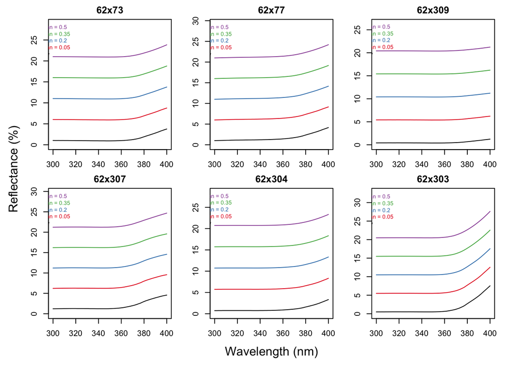

```r
# Plot to determine suitable smoothing span
plotsmooth(bract_spec_avg[,1:7],
           minsmooth = 0.05,
           maxsmooth = 0.5,
           curves = 4,
           ask = FALSE)
```

Choose a span (e.g., 0.2) based on the plot to balance smoothness and data fidelity.

## 5.6 Smooth the Spectral Data

Apply smoothing to the spectral data using the chosen span.

```r
# Apply smoothing with span = 0.2
bract_spec_sm <- procspec(bract_spec_avg, opt = "smooth", span = 0.2)
```

```
## processing options applied:
## smoothing spectra with a span of 0.2
```

```r
petal_spec_sm <- procspec(petal_spec_avg, opt = "smooth", span = 0.2)
```

```
## processing options applied:
## smoothing spectra with a span of 0.2
```

```r
labellum_spec_sm <- procspec(labellum_spec_avg, opt = "smooth", span = 0.2)
```

```
## processing options applied:
## smoothing spectra with a span of 0.2
```

## 5.7 Scale the Spectral Data

Scale the spectral data to different reference points for comparative analysis.

```r
# Scale spectra to both minimum and maximum reflectance
bract_spec_scalemax_UV <- procspec(bract_spec_sm, opt = c("min", "max"))
```

```
## processing options applied:
## Scaling spectra to a minimum value of zero
## Scaling spectra to a maximum value of 1
```

```r
petal_spec_scalemax_UV <- procspec(petal_spec_sm, opt = c("min", "max"))
```

```
## processing options applied:
## Scaling spectra to a minimum value of zero
## Scaling spectra to a maximum value of 1
```

```r
labellum_spec_scalemax_UV <- procspec(labellum_spec_sm, opt = c("min", "max"))
```

```
## processing options applied:
## Scaling spectra to a minimum value of zero
## Scaling spectra to a maximum value of 1
```

## 5.8 Plot Processed Spectra

Visualize the processed spectral data for each floral tissue, highlighting specific samples.

## 5.9 Define Common Plotting Parameters

```r
# Define a color palette for highlighting specific samples
highlight_colors <- c(rep("lightgrey", 170), "gold1", "gold1", "darkgreen")
```

## 5.10 Bract Spectra Plot

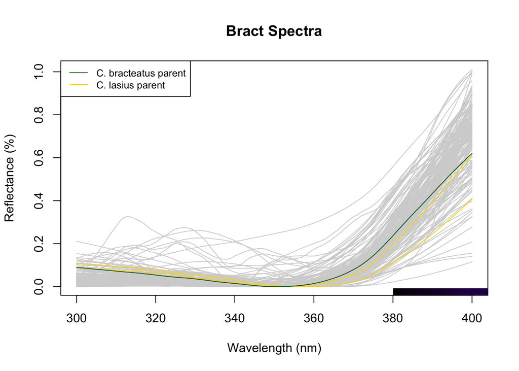

```r
# Order samples to highlight specific ones
order_spec_bract <- c(
  which(names(bract_spec_scalemax_UV) == "125"),
  which(names(bract_spec_scalemax_UV) == "126"),
  which(names(bract_spec_scalemax_UV) == "BRAC")
)

# Reorder columns to place highlighted samples at the end
columns_bract <- 1:ncol(bract_spec_scalemax_UV)
order_spec_bract <- c(columns_bract[columns_bract %notin% order_spec_bract], order_spec_bract)

# Plot the spectra
plot(bract_spec_scalemax_UV[order_spec_bract], type = "o",
     col = highlight_colors, main = "Bract Spectra",
     xlab = "Wavelength (nm)", ylab = "Reflectance (%)")

# Add a legend
legend("topleft", legend = c("C. bracteatus parent", "C. lasius parent"),
       col = c("darkgreen", "gold1"), lty = 1, cex = 0.8)
```

## 5.11 Petal Spectra Plot

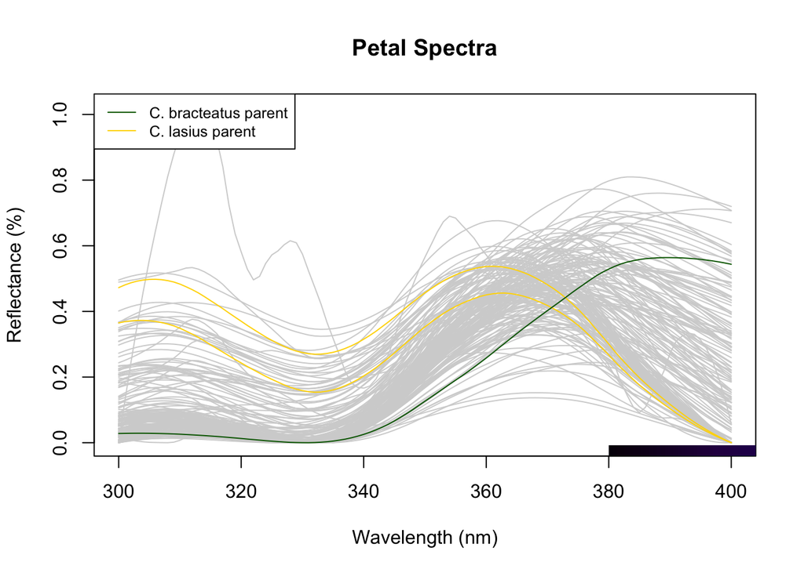

```r
# Order samples to highlight specific ones
order_spec_petal <- c(
  which(names(petal_spec_scalemax_UV) == "125"),
  which(names(petal_spec_scalemax_UV) == "126"),
  which(names(petal_spec_scalemax_UV) == "BRAC")
)

# Reorder columns to place highlighted samples at the end
columns_petal <- 1:ncol(petal_spec_scalemax_UV)
order_spec_petal <- c(columns_petal[columns_petal %notin% order_spec_petal], order_spec_petal)

# Plot the spectra
plot(petal_spec_scalemax_UV[order_spec_petal], type = "o",
     col = highlight_colors, main = "Petal Spectra",
     xlab = "Wavelength (nm)", ylab = "Reflectance (%)")

# Add a legend
legend("topleft", legend = c("C. bracteatus parent", "C. lasius parent"),
       col = c("darkgreen", "gold1"), lty = 1, cex = 0.8)
```

## 5.12 Labellum Spectra Plot

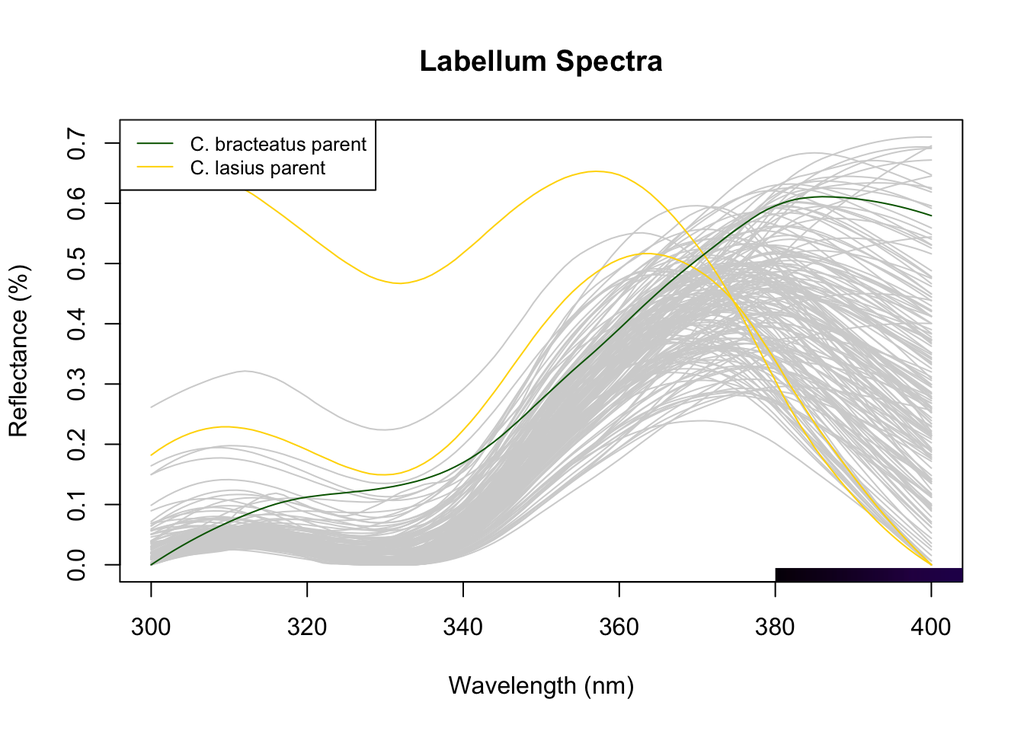

```r
# Order samples to highlight specific ones
order_spec_labellum <- c(
  which(names(labellum_spec_scalemax_UV) == "125"),
  which(names(labellum_spec_scalemax_UV) == "126"),
  which(names(labellum_spec_scalemax_UV) == "BRAC")
)

# Reorder columns to place highlighted samples at the end
columns_labellum <- 1:ncol(labellum_spec_scalemax_UV)
order_spec_labellum <- c(columns_labellum[columns_labellum %notin% order_spec_labellum], order_spec_labellum)

# Plot the spectra
plot(labellum_spec_scalemax_UV[order_spec_labellum], type = "o",
     col = highlight_colors, main = "Labellum Spectra",
     xlab = "Wavelength (nm)", ylab = "Reflectance (%)")

# Add a legend
legend("topleft", legend = c("C. bracteatus parent", "C. lasius parent"),
       col = c("darkgreen", "gold1"), lty = 1, cex = 0.8)
```

## 5.13 Combine and Save Spectral Plots with Highlighted Parents

```r
# Save combined spectra plots with highlighted parental samples
pdf("./results/figures/Combined_UVspectra_Bract_Petal_Labellum_Cbracteatus_Clasius_hybrids.pdf", width = 30, height = 7)
par(mfrow = c(1, 3))
# Increase left margin to provide more space for y-axis labels
par(mar = c(5, 5, 4, 2) + 0.1)  # c(bottom, left, top, right)
plot(bract_spec_scalemax_UV[order_spec_bract], type = "o", col = highlight_colors,
     main = "Bract spectra", xlab = "Wavelength (nm)", ylab = "Reflectance (%)",
     cex.main = 3, cex.lab = 2.5, cex.axis = 2, lwd = 2)
legend("topleft", legend = c("C. bracteatus parent", "C. lasius parent"),
       col = c("darkgreen", "gold1"), lty = 1, cex = 2.5, bty = "n")
plot(petal_spec_scalemax_UV[order_spec_petal], type = "o", col = highlight_colors,
     main = "Petal spectra", xlab = "Wavelength (nm)", ylab = "Reflectance (%)",
     cex.main = 3, cex.lab = 2.5, cex.axis = 2, lwd = 2)
legend("topleft", legend = c("C. bracteatus parent", "C. lasius parent"),
       col = c("darkgreen", "gold1"), lty = 1, cex = 2.5, bty = "n")
plot(labellum_spec_scalemax_UV[order_spec_labellum], type = "o", col = highlight_colors,
     main = "Labellum spectra", xlab = "Wavelength (nm)", ylab = "Reflectance (%)",
     cex.main = 3, cex.lab = 2.5, cex.axis = 2, lwd = 2)
legend("topleft", legend = c("C. bracteatus parent", "C. lasius parent"),
       col = c("darkgreen", "gold1"), lty = 1, cex = 2.5, bty = "n")
dev.off()
```

## 5.14 Spectral Descriptors

We compute various spectral descriptors to quantify the color properties of the floral tissues.

## 5.15 Define spectral descriptors

B1: Total brightness B2: Mean brightness B3: Intensity (Rmax) S1U to S1R: Relative contributions of UV, Violet, Blue, Green, Yellow, and Red spectral ranges to total brightness S2: Spectral saturation (Rmax/Rmin) S3: Chroma S4: Spectral purity S5: Chroma S6: Contrast (Rmax - Rmin) S7: Spectral saturation S8: Chroma ((Rmax - Rmin)/B2) S9: Carotenoid chroma ((R700 - R450)/R700) S10: Peaky chroma H1 to H5: Hue metrics (e.g., peak wavelength) Note: Some metrics may be sensitive to spectral noise.

## 5.16 Calculate Spectral Descriptors

### 5.16.1 Bract

```r
# Calculate spectral descriptors for bract
summary_bract_UV <- summary(bract_spec_scalemax_UV)
# Remove S2 due to infinite values
summary_bract_UV <- summary_bract_UV %>% select(-S2)

# Extract metrics for parents
bract125 <- round(summary_bract_UV["125", ], 3)
bract126 <- round(summary_bract_UV["126", ], 3)
bractBRAC <- round(summary_bract_UV["BRAC", ], 3)
```

### 5.16.2 Plot Bract Spectral Descriptors Histograms

```r
pdf("./results/figures/bract_UV_descriptors_histograms.pdf", width = 14, height = 10)

# Set up plotting area: 4 rows x 6 columns for histograms
par(mfrow = c(4, 6),        # 4 rows, 6 columns
    mar = c(5, 5, 4, 2) + 0.1,  # Margins for each plot: bottom, left, top, right
    oma = c(0, 0, 0, 5))    # Outer margins: bottom, left, top, right

# Loop through each metric and plot histogram with parental lines
for (i in 1:ncol(summary_bract_UV)) {

  if (!any(!is.na(summary_bract_UV[, i]))) next  # Skip columns that are entirely NA

  hist(summary_bract_UV[, i],
       xlab = colnames(summary_bract_UV)[i],
       main = colnames(summary_bract_UV)[i],
       col = "lightgrey",
       border = "white")

  # Add vertical lines for parental samples
  abline(v = bract125[i], col = 'gold1', lwd = 3)      # C. lasius parent
  abline(v = bract126[i], col = 'gold1', lwd = 3)      # C. lasius parent
  abline(v = bractBRAC[i], col = 'darkgreen', lwd = 3) # C. bracteatus parent
}

# Allow drawing in the outer margin
par(xpd = TRUE)

plot.new()

# Add a shared legend in the outer right margin
legend("topright",
       inset = c(0, 0),  # Adjusts the position of the legend
       legend = c("C. lasius parent", "C. bracteatus parent"),
       col = c("gold1", "darkgreen"),
       lty = 1,              # Line type: solid
       lwd = 3,              # Line width
       cex = 1.5,            # Text size
       bty = "n")            # No box around the legend

# Close the PDF device to save the file
dev.off()
```

### 5.16.3 Petal Summary

```r
# Calculate summary statistics for petal
summary_petal_UV <- summary(petal_spec_scalemax_UV)
# Remove S2 due to infinite values
summary_petal_UV <- summary_petal_UV %>% select(-S2)

# Extract metrics for specific samples
petal125 <- round(summary_petal_UV["125", ], 3)
petal126 <- round(summary_petal_UV["126", ], 3)
petalBRAC <- round(summary_petal_UV["BRAC", ], 3)
```

### 5.16.4 Plot Petal Spectral Descriptors Histograms

```r
pdf("./results/figures/petal_UV_descriptors_histograms.pdf", width = 14, height = 10)

# Set up plotting area: 4 rows x 6 columns for histograms
par(mfrow = c(4, 6),        # 4 rows, 6 columns
    mar = c(5, 5, 4, 2) + 0.1,  # Margins for each plot: bottom, left, top, right
    oma = c(0, 0, 0, 5))    # Outer margins: bottom, left, top, right

# Loop through each metric and plot histogram with parental lines
for (i in 1:ncol(summary_petal_UV)) {

  if (!any(!is.na(summary_petal_UV[, i]))) next  # Skip columns that are entirely NA

  hist(summary_petal_UV[, i],
       xlab = colnames(summary_petal_UV)[i],
       main = colnames(summary_petal_UV)[i],
       col = "lightgrey",
       border = "white")

  # Add vertical lines for parental samples
  abline(v = petal125[i], col = 'gold1', lwd = 3)      # C. lasius parent
  abline(v = petal126[i], col = 'gold1', lwd = 3)      # C. lasius parent
  abline(v = petalBRAC[i], col = 'darkgreen', lwd = 3) # C. bracteatus parent
}

# Allow drawing in the outer margin
par(xpd = TRUE)

plot.new()

# Add a shared legend in the outer right margin
legend("topright",
       inset = c(0, 0),  # Adjusts the position of the legend
       legend = c("C. lasius parent", "C. bracteatus parent"),
       col = c("gold1", "darkgreen"),
       lty = 1,              # Line type: solid
       lwd = 3,              # Line width
       cex = 1.5,            # Text size
       bty = "n")            # No box around the legend

# Close the PDF device to save the file
dev.off()
```

### 5.16.5 Labellum Summary

```r
# Calculate summary statistics for labellum
summary_labellum_UV <- summary(labellum_spec_scalemax_UV)
# Remove S2 due to infinite values
summary_labellum_UV <- summary_labellum_UV %>% select(-S2)

# Extract metrics for specific samples
labellum125 <- round(summary_labellum_UV["125", ], 3)
labellum126 <- round(summary_labellum_UV["126", ], 3)
labellumBRAC <- round(summary_labellum_UV["BRAC", ], 3)
```

### 5.16.6 Plot Labellum Spectral Descriptors Histograms

```r
pdf("./results/figures/labellum_UV_descriptors_histograms.pdf", width = 14, height = 10)

# Set up plotting area: 4 rows x 6 columns for histograms
par(mfrow = c(4, 6),        # 4 rows, 6 columns
    mar = c(5, 5, 4, 2) + 0.1,  # Margins for each plot: bottom, left, top, right
    oma = c(0, 0, 0, 5))    # Outer margins: bottom, left, top, right

# Loop through each metric and plot histogram with parental lines
for (i in 1:ncol(summary_labellum_UV)) {

  if (!any(!is.na(summary_labellum_UV[, i]))) next  # Skip columns that are entirely NA

  hist(summary_labellum_UV[, i],
       xlab = colnames(summary_labellum_UV)[i],
       main = colnames(summary_labellum_UV)[i],
       col = "lightgrey",
       border = "white")

  # Add vertical lines for parental samples
  abline(v = labellum125[i], col = 'gold1', lwd = 3)      # C. lasius parent
  abline(v = labellum126[i], col = 'gold1', lwd = 3)      # C. lasius parent
  abline(v = labellumBRAC[i], col = 'darkgreen', lwd = 3) # C. bracteatus parent
}

# Allow drawing in the outer margin
par(xpd = TRUE)

plot.new()

# Add a shared legend in the outer right margin
legend("topright",
       inset = c(0, 0),  # Adjusts the position of the legend
       legend = c("C. lasius parent", "C. bracteatus parent"),
       col = c("gold1", "darkgreen"),
       lty = 1,              # Line type: solid
       lwd = 3,              # Line width
       cex = 1.5,            # Text size
       bty = "n")            # No box around the legend

# Close the PDF device to save the file
dev.off()
```

## 5.17 Data Formatting and Export

## 5.18 Reformat Rownames

Replace ‘x’ with ’_’ in row names for consistency.

```r
# Replace 'x' with '_' in row names
rownames(summary_bract_UV) <- gsub("x", "_", rownames(summary_bract_UV))
rownames(summary_petal_UV) <- gsub("x", "_", rownames(summary_petal_UV))
rownames(summary_labellum_UV) <- gsub("x", "_", rownames(summary_labellum_UV))
```

## 5.19 Convert Rownames to a Column

Add the row names as a new column id to facilitate merging.

```r
# Convert row names to a column named 'id'
summary_petal_UV <- summary_petal_UV %>% rownames_to_column(var = "id")
summary_labellum_UV <- summary_labellum_UV %>% rownames_to_column(var = "id")
```

## 5.20 Subset and Rename Columns

Select relevant metrics and rename columns to indicate their corresponding floral tissue.

```r
# Subset relevant columns based on analysis needs
summary_petal_UV <- summary_petal_UV[, c("id", "H1")]
summary_labellum_UV <- summary_labellum_UV[, c("id", "H1")]

# Rename columns to include tissue type
colnames(summary_petal_UV) <- c("id", "H1_UV_petal")
colnames(summary_labellum_UV) <- c("id", "H1_UV_labellum")
```

# 6 Vision Models

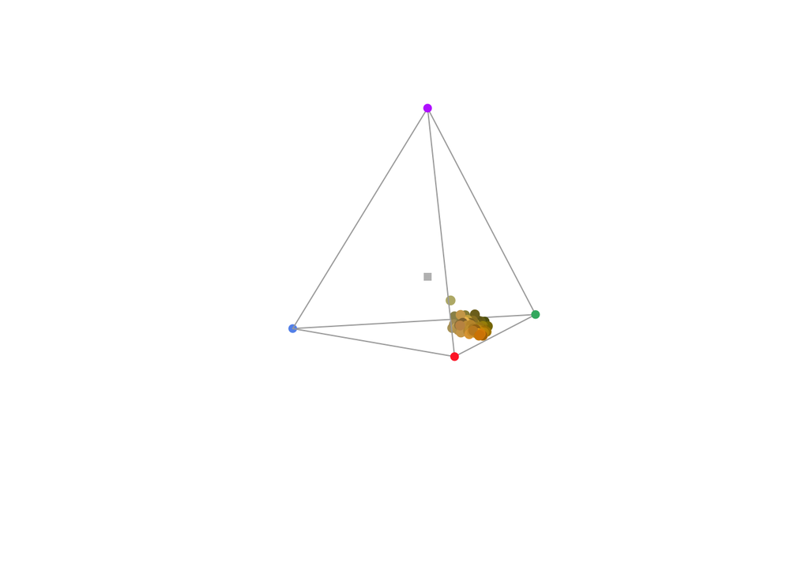

```r
# Compute Photoreceptor Quantum Catches for Birds and Bees
## Bract
bract_bird_vis <- vismodel(bract_spec_scalemax, visual = "avg.uv", relative = TRUE)
bract_bee_vis <- vismodel(bract_spec_scalemax, visual = "apis", relative = TRUE)

## Petal
petal_bird_vis <- vismodel(petal_spec_scalemax, visual = "avg.uv", relative = TRUE)
petal_bee_vis <- vismodel(petal_spec_scalemax, visual = "apis", relative = TRUE)

## Labellum
labellum_bird_vis <- vismodel(labellum_spec_scalemax, visual = "avg.uv", relative = TRUE)
labellum_bee_vis <- vismodel(labellum_spec_scalemax, visual = "apis", relative = TRUE)

# Convert Bird Vision Data into a Color Space
bract_bird_colspace <- colspace(bract_bird_vis, space = "auto")
petal_bird_colspace <- colspace(petal_bird_vis, space = "auto")
labellum_bird_colspace <- colspace(labellum_bird_vis, space = "auto")

# Plot the Avian Color Space Representation
plot(bract_bird_colspace, col = spec2rgb(bract_spec_scalemax))
```

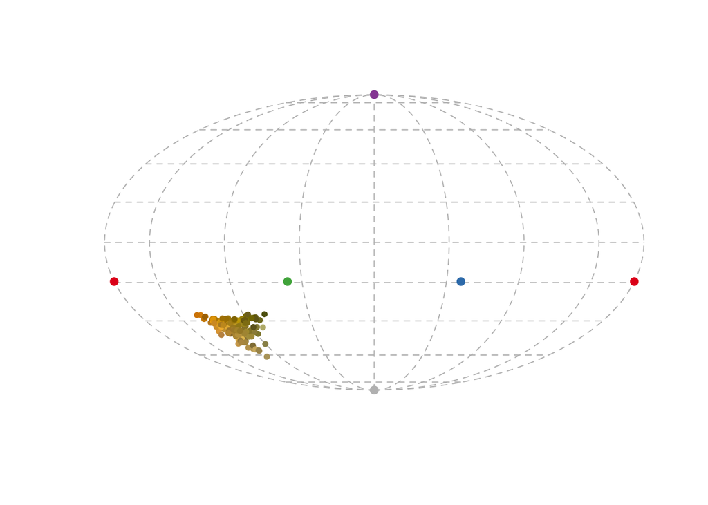

```r
projplot(bract_bird_colspace, pch = 20, col = spec2rgb(bract_spec_scalemax))
```

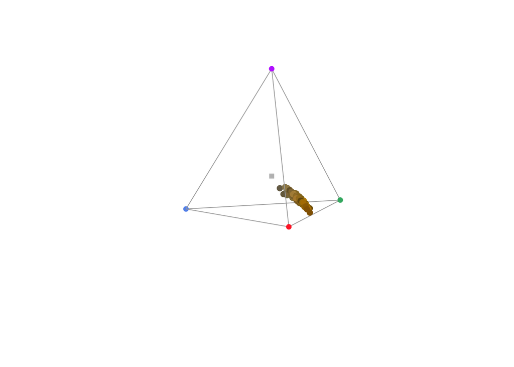

```r
plot(petal_bird_colspace, col = spec2rgb(petal_spec_scalemax))
```

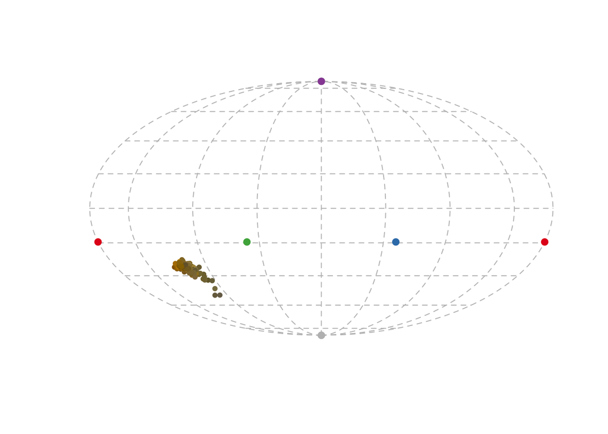

```r
projplot(petal_bird_colspace, pch = 20, col = spec2rgb(petal_spec_scalemax))
```

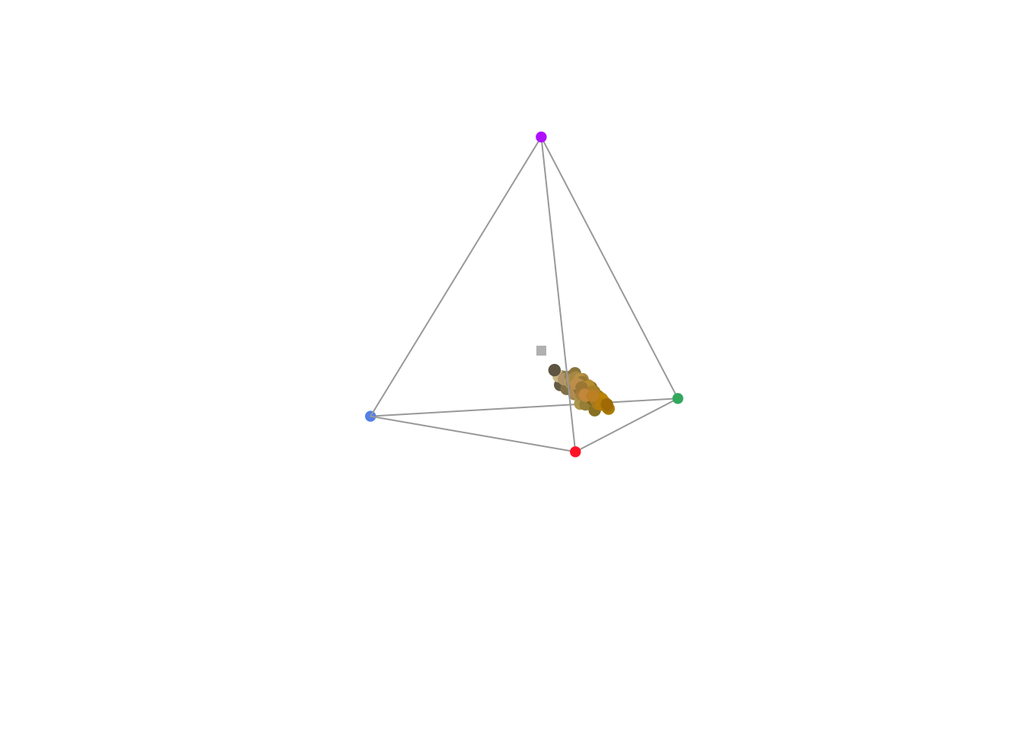

```r
plot(labellum_bird_colspace, col = spec2rgb(labellum_spec_scalemax))
```

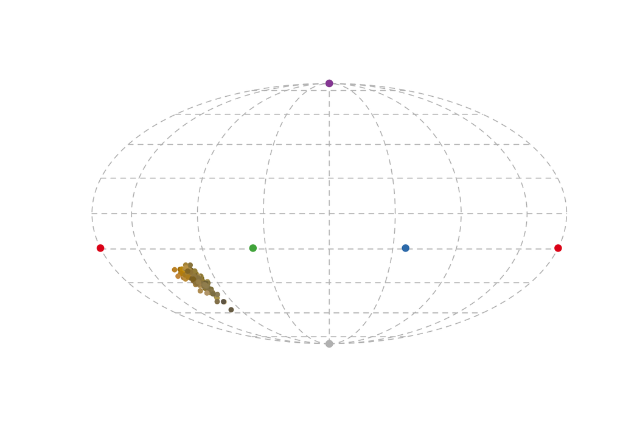

```r
projplot(labellum_bird_colspace, pch = 20, col = spec2rgb(labellum_spec_scalemax))
```

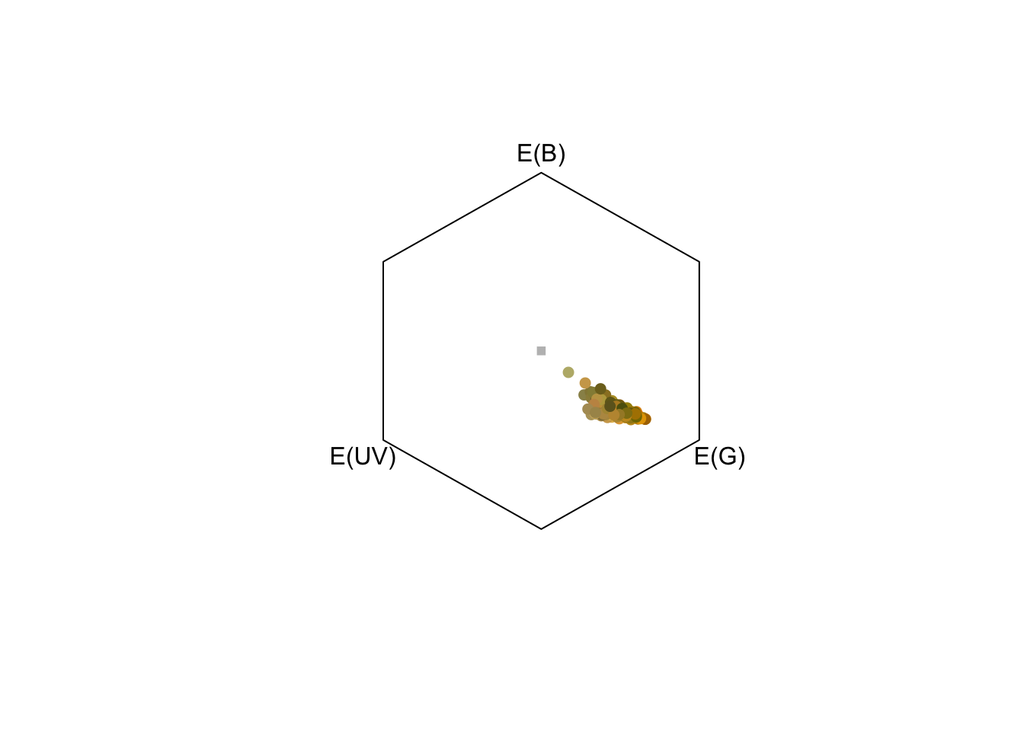

```r
# Convert Bee Vision Data into a Color Space
bract_bee_colspace <- colspace(bract_bee_vis, space = "tri")
petal_bee_colspace <- colspace(petal_bee_vis, space = "tri")
labellum_bee_colspace <- colspace(labellum_bee_vis, space = "tri")

# Plot the Bee Color Space Representation
hexplot(bract_bee_colspace, col = spec2rgb(bract_spec_scalemax))
```

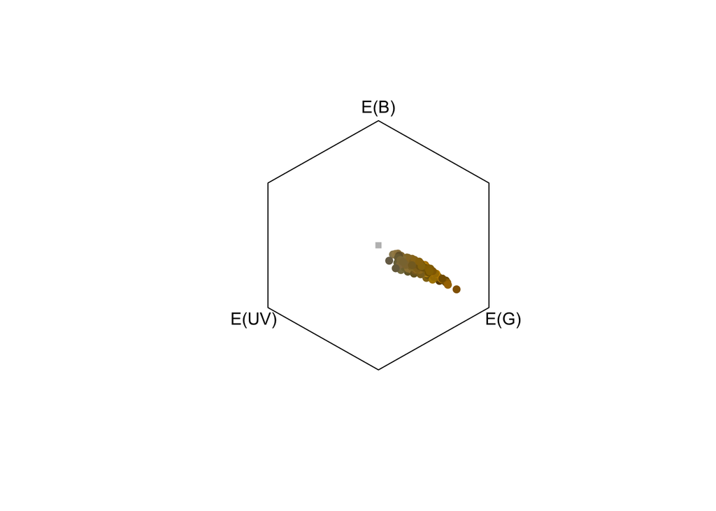

```r
hexplot(petal_bee_colspace, col = spec2rgb(petal_spec_scalemax))
```

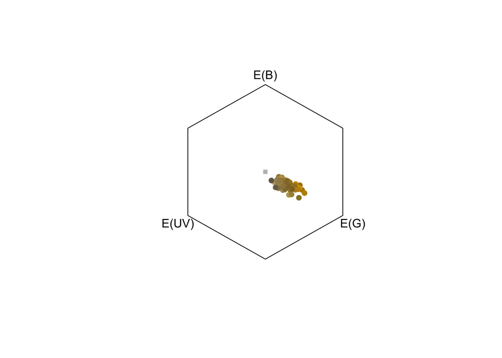

```r
hexplot(labellum_bee_colspace, col = spec2rgb(labellum_spec_scalemax))
```

```r
# Replace 'x' with '_' in row names
rownames(bract_bird_colspace) <- gsub("x", "_", rownames(bract_bird_colspace))
rownames(bract_bee_colspace) <- gsub("x", "_", rownames(bract_bee_colspace))

rownames(petal_bird_colspace) <- gsub("x", "_", rownames(petal_bird_colspace))
rownames(petal_bee_colspace) <- gsub("x", "_", rownames(petal_bee_colspace))

rownames(labellum_bird_colspace) <- gsub("x", "_", rownames(labellum_bird_colspace))
rownames(labellum_bee_colspace) <- gsub("x", "_", rownames(labellum_bee_colspace))

# Convert row names to a column named 'id'
bract_bird_colspace <- bract_bird_colspace %>% rownames_to_column(var = "id")
bract_bee_colspace <- bract_bee_colspace %>% rownames_to_column(var = "id")

petal_bird_colspace <- petal_bird_colspace %>% rownames_to_column(var = "id")
petal_bee_colspace <- petal_bee_colspace %>% rownames_to_column(var = "id")

labellum_bird_colspace <- labellum_bird_colspace %>% rownames_to_column(var = "id")
labellum_bee_colspace <- labellum_bee_colspace %>% rownames_to_column(var = "id")

# Subset relevant columns based on analysis needs
bract_bird_colspace <- bract_bird_colspace[, c("id", "h.theta", "r.vec")]
bract_bee_colspace <- bract_bee_colspace[, c("id", "h.theta", "r.vec")]

petal_bird_colspace <- petal_bird_colspace[, c("id", "h.theta", "r.vec")]
petal_bee_colspace <- petal_bee_colspace[, c("id", "h.theta", "r.vec")]

labellum_bird_colspace <- labellum_bird_colspace[, c("id", "h.theta", "r.vec")]
labellum_bee_colspace <- labellum_bee_colspace[, c("id", "h.theta", "r.vec")]

# Rename columns to include tissue type
colnames(bract_bird_colspace) <- c("id", "h.theta.bird.bract", "r.vec.bird.bract")
colnames(bract_bee_colspace) <- c("id", "h.theta.bee.bract", "r.vec.bee.bract")

colnames(petal_bird_colspace) <- c("id", "h.theta.bird.petal", "r.vec.bird.petal")
colnames(petal_bee_colspace) <- c("id", "h.theta.bee.petal", "r.vec.bee.petal")

colnames(labellum_bird_colspace) <- c("id", "h.theta.bird.labellum", "r.vec.bird.labellum")
colnames(labellum_bee_colspace) <- c("id", "h.theta.bee.labellum", "r.vec.bee.labellum")
```

# 7 Merge Dataframes

```r
# Merge all summaries by 'id'
joined_df <- pca_bract %>%
  full_join(pca_petal, by = "id") %>%
  full_join(pca_labellum, by = "id") %>%
  full_join(summary_bract, by = "id") %>%
  full_join(summary_petal, by = "id") %>%
  full_join(summary_labellum, by = "id") %>%
  full_join(summary_petal_UV, by = "id") %>%
  full_join(summary_labellum_UV, by = "id") %>%
  full_join(bract_bird_colspace, by = "id") %>%
  full_join(bract_bee_colspace, by = "id") %>%
  full_join(petal_bird_colspace, by = "id") %>%
  full_join(petal_bee_colspace, by = "id") %>%
  full_join(labellum_bird_colspace, by = "id") %>%
  full_join(labellum_bee_colspace, by = "id")
```

# 8 Export Summary Descriptors to CSV

Save the combined summary descriptors to a CSV file for further analysis or reporting.

```r
# Write the combined summary dataframe to a CSV file
write.csv(joined_df, "./results/processed_data/color_traits.csv",
          quote = FALSE, row.names = FALSE)
```